# miRetrieve

microRNA text mining in PubMed abstracts

Julian Friedrich<sup>1,2</sup>, Hans-Peter Hammes<sup>2, 3</sup>, Guido Krenning<sup>1</sup> <sup>1</sup>Cardiovascular Regenerative Medicine (CAVAREM), Department of Pathology and Medical Biology, University Medical Center Groningen, University of Groningen, The Netherlands. <sup>2</sup>Section of Endocrinology, 5th Medical Department, Medical Faculty of Mannheim, University of Heidelberg, Mannheim, Germany. <sup>3</sup>European Center of Angioscience, Medical Faculty Mannheim, Heidelberg University, Germany

2019-12-03

# 1 Introduction

miRetrieve is an R package designed to facilitate text mining with microRNAs (miRNAs) in PubMed abstracts. By extracting miRNA names from large amounts of text, miRetrieve is able to provide insights into thousands of articles within a short amount of time.

In this vignette, we describe how to use miRetrieve. First, we are going to illustrate the mechanisms underlying miRetrieve by introducing basic tools of text analysis, which is a part of *Natural Language Processing* (NLP). Next, we are going to explain how to use the functions in miRetrieve, before applying miRetrieve in a case study.

# 2 Natural Language Processing

**Natural Language Processing (NLP)** describes the application of computational methods to process and analyze language[^1].

In this section, we are going to present common tools in NLP, namely *tokenization*, *tf-idf*, *stop word removal*, and *topic modeling*. These tools aid in gaining and extracting insights from a collection of texts, which are contained in a **corpus**.  
While this list is not exhaustive, it illustrates the mechanisms underlying many functions in miRetrieve and makes their use transparent.

## 2.1 Tokenization

**Tokenization** refers to splitting text into smaller pieces, called *tokens*.

While text can be tokenized in many different ways, two common approaches are **single word tokenization** and **n-gram tokenization** (Fig. 2.1).  
Whereas single word tokenization splits text into single words (Fig. 2.1 **A**), n-gram tokenization splits text into each combination of *n* adjacent words, which are referred to as *2-grams*, *3-grams* etc. (Fig. 2.1 **B**).  
During tokenization, capital letters are transformed into lower case letters and punctuation such as **.** , **,** , or **-** is substituted with a space, if not specified otherwise. As a result, terms such as *T1DM* are transformed into *t1dm*, while compound terms such as *low-density* are tokenized into *low* and *density*.

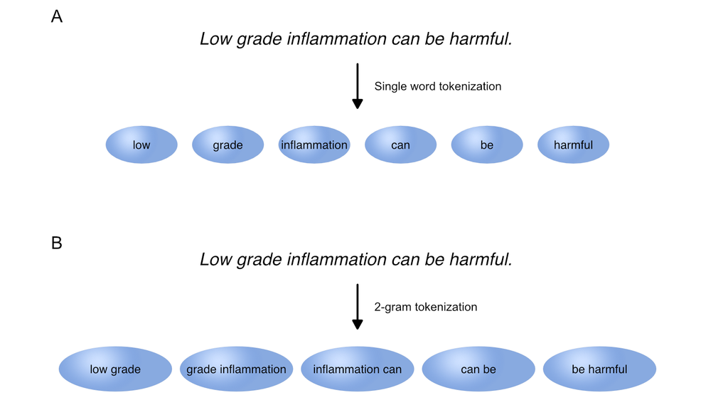

Figure 2.1: **Tokenization in NLP.** Tokenization refers to splitting text into smaller pieces, called tokens. Two common tokenization approaches are single word tokenization **(A)** and n-gram tokenization, splitting text into each combination of n adjacent words such as 2-grams **(B)**.

After a text is tokenized, the frequency of each token can provide first insights into the overall subject of the text. If *inflammation* is one of the most frequent tokens in a text, it can also be assumed that *inflammation* partially describes the topic of the text. Furthermore, token frequency can be compared between texts and serve as a starting point to determine text (dis)similarity.

While single word tokenization makes text comparison easy, complex n-grams may impede direct comparison. To meaningfully compare the token frequency of the 2-gram *low grade*, for example, requires many texts to have the exact same combination of *low* and *grade* multiple times, whereas it is clear that the chance of same word combinations decreases when n-gram size increases.

However, n-grams shine when word context matters. Single word tokenization of *Low grade inflammation* (*low*, *grade*, *inflammation*) loses the context of *low*, and if *low* is used in the context of *low grade inflammation*, *low expression*, or even *low-density lipoprotein* is not clear. After tokenizing *Low grade inflammation* into 2-grams, however, the token *low grade* hints that *low* is neither associated with *expression* nor with *low-density lipoprotein*, which already provides more insight into the context of *low*.

When a function depends on tokenization in miRetrieve, the tokenization type can usually be set via the `token` argument. `token = "words"` performs single word tokenization, while `token = "ngrams"` and a specified `n` argument performs n-gram tokenization.

```r
# Analyze miRNA-term association of miR-34 by single word tokenization
plot_mir_terms(df,
               mir = "miR-34",
               token = "words")

# Analyze miRNA-term association of miR-34 by 2-gram tokenization
plot_mir_terms(df,
               mir = "miR-34",
               token = "ngrams",
               n = 2)
```

## 2.2 tf-idf

**term frequency–inverse document frequency**, or **tf-idf** in short, determines how unique and important a token is to one text compared to other texts.

Instead of comparing raw token frequency between texts, tokens are “weighed” depending on how often they are mentioned in one text compared to all other texts under investigation.  
When tokenizing the texts

- *Cancer can affect any organ.*
- *Cancer can be caused by mutations.*
- *Cancer can be caused by viruses*

into single words, the tokens *cancer* and *can* are present in all three texts, while the tokens *be*, *caused*, and *by* are present in two out of three texts. The tokens *affect*, *any*, *organ*, *mutations*, and *viruses*, however, are only present in one text compared to all other texts. Taken together, this suggests that the tokens *cancer* and *can* offer no information when distinguishing these texts, while the text specific tokens *organ*, *mutations*, and *viruses* make the texts distinguishable and are thus more important for each text.

In miRetrieve, tf-idf can be used to determine how important a term is to a miRNA compared to other miRNAs in a corpus. If *inflammation* is only associated with miR-146, but not associated with miR-374 or miR-23, then *inflammation* is very specific for miR-146.  
When a miRetrieve function offers tf-idf analysis, such as `plot_mir_terms()` or `plot_wordcloud()`, it can be applied by setting `tf.idf = TRUE`.

```r
# Analyze miRNA-term association of miR-34 with tf-idf
plot_mir_terms(df,
               mir = "miR-34",
               tf.idf = TRUE)

# Analyze miRNA-term association of miR-34 without tf-idf
plot_mir_terms(df,
               mir = "miR-34",
               tf.idf = FALSE)
```

## 2.3 Stop words

**Stop words** refer to common words that offer no information for text analysis, such as *a*, *is*, or *whether*, and are thus often removed (Fig. 2.2).

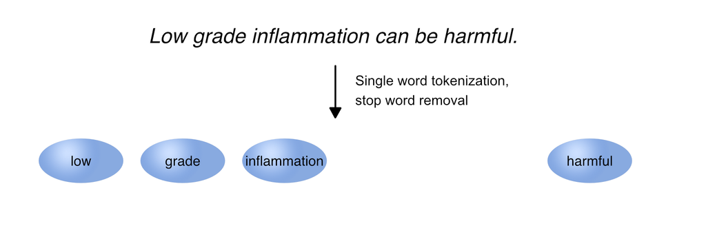

Figure 2.2: **Stop word removal.** Stop words refer to common words that offer no information for text analysis. It is therefore common practice to remove stop words in text analysis.

In miRetrieve, stop words are removed in two ways depending on tokenization type, namely stop word removal for single word tokenization and stop word removal for n-gram tokenization.

### 2.3.1 Stop words for single word tokenization

To remove stop words for single word tokenization, stop words must be provided in a data frame. miRetrieve comes with predefined stop words, namely `stopwords_miretrieve`, which combines English stop words[^2], such as *a*, *is*, or *whether*, with stop words of PubMed abstracts, such as *western*, *qpcr*, or *significant*.

```r
# Remove common English and PubMed words with `stopwords_miretrieve`
plot_mir_terms(df,
               mir = "miR-34",
               stopwords = stopwords_miretrieve)
```

If only English stop words shall be removed, `stop_words` from the **tidytext** package can be used.

```r
# Remove common English words with `stop_words` from tidytext
plot_mir_terms(df,
               mir = "miR-34",
               stopwords = tidytext::stop_words)
```

Additionally, stop words can be generated from custom terms with `generate_stopwords()`. These generated stop words can be added to an existing stop word data frame using the argument `combine_with`. Additionally, several stop words data frames can be combined with `combine_stopwords()`.

```r
# Vector of custom stop words
custom_stopwords <- c("these", "are", "some", "custom", "stop", "words")

# Generate custom stop words data frame
# Combine custom stop words with `stopwords_miretrieve`
custom_stopwords_df <- generate_stopwords(custom_stopwords,
                                          combine_with = stopwords_miretrieve)

# Generate custom stop words data frame
# Combine with `tidytext::stop_words` separately
custom_stopwords_df <- generate_stopwords(custom_stopwords)
stopwords_combined <- combine_stopwords(custom_stopwords_df,
                                        tidytext::stop_words)
```

### 2.3.2 Stop words for n-gram tokenization

For n-gram tokenization, miRetrieve removes English stop words and PubMed stop words separately. First, English stop words[^3] are removed, and n-gram stop words are removed afterwards. The separation in stop word removal for English and n-gram stop words is explained by the increase in complexity with bigger n-grams.  
While English stop words are removed by setting `stopwords_ngram = TRUE`, n-grams to be removed must be provided in a data frame. `stopwords_miretrieve` removes common 2-grams, while stop words for bigger n-grams must be generated manually with `generate_stopwords()`.

```r
# Remove English stop words for 2-gram tokenization
# Remove PubMed 2-grams with `stopwords_miretrieve`
plot_mir_terms(df,
               mir = "miR-34",
               token = "ngrams",
               n = 2,
               stopwords = stopwords_miretrieve,
               stopwords_ngram = TRUE)
```

## 2.4 Topic modeling

**topic modeling** describes the identification of topics in a corpus. Topics can either be identified in a supervised, e.g. controlled manner, or in an unsupervised, e.g. blind manner.

### 2.4.1 Supervised topic modeling

**Supervised topic modeling** refers to identifying known topics in a corpus, and thus requires prior knowledge.

miRetrieve offers supervised topic modeling by heuristically identifying topics with keywords: First, a topic is defined by keywords, and these keywords are then used to calculate a *topic score* for each text in the corpus. The topic score reflects how well a text matches the keywords, and if the topic score surpasses a threshold, the text is considered to match the topic.

There are three pre-implemented heuristic topic models in miRetrieve, namely

- abstracts that investigate miRNAs in patients,
- abstracts that investigate miRNAs in animal models,
- abstracts that investigate miRNAs as biomarkers.

While knowledge about how often a miRNA has been investigated in patients or in animal models can estimate the translation between bench and bedside, identifying which miRNA is most likely a biomarker aids in estimating its specificity compared to other fields.

For each heuristic model, a topic score can be calculated using `calculate_score_patients()`, `calculate_score_animals()`, and `calculate_score_biomarker()`. Furthermore, each `calculate_score_*()` function has a corresponding `plot_score_*()` function (`plot_score_patients()`, `plot_score_animals()`, and `plot_score_biomarkers()`), which plots the distribution of scores across all abstracts, and helps in choosing a threshold for topic assignment.

```r
# Plot score distribution, determine threshold
plot_score_patients(df)

# Calculate score for abstracts investigating miRNAs in patients
calculate_score_patients(df,
                         threshold = 5)
```

Next to the pre-implemented models, custom topics can be defined with custom keywords using `calculate_score_topic()` and its corresponding `plot_score_topic()` function.

```r
# Define keywords of custom topic "angiogenesis"
keywords_angiogenesis <- c("angiogenesis", "vegf", "vascularization",
                           "sprouting")

# Plot distribution of "angiogenesis" scores
plot_score_topic(df,
                 keywords = keywords_angiogenesis,
                 name.topic = "Angiogenesis")

# Calculate angiogenesis score for each abstract
df_angio <- calculate_score_topic(df,
                                  keywords = keywords_angiogenesis,
                                  threshold = 3)
```

While one abstract can belong to multiple topics, abstracts can also be assigned to only one out of two or more topics: First, topic scores for all topics of interest are calculated, using `calculate_score_topic()`. Afterwards, each abstract is assigned to the topic where it surpasses a threshold and achieves the highest topic score,  
using `assign_topic()`. If the topic score of an abstract does not surpass the threshold in any topic, the topic of the abstract is labelled as `"Unknown"`.

```r
# Define keywords for type 1 diabetes
keywords_t1dm <- c("pancreas", "beta cells", "gada")

# Define keywords for type 2 diabetes
keywords_t2dm <- c("insulin resistance", "obesity", "metformin")

# Calculate type 1 diabetes scores for each abstract
df_diabetes <- calculate_score_topic(df,
                                     keywords = keywords_t1dm,
                                     name.topic = "T1DM")

# Calculate type 2 diabetes scores for each abstract
df_diabetes <- calculate_score_topic(df_diabetes,
                                     keywords = keywords_t2dm,
                                     name.topic = "T2DM")

# Assign abstracts with a score of >= 3 in "T1DM" to type 1 diabetes
# Assign abstracts with a score of >= 3 in "T2DM" to type 2 diabetes
# Abstracts with a score < 3 in "T1DM" and "T2DM" are assigned to
# "Unknown".
assign_topic(df_diabetes,
             col.topic = c("T1DM", "T2DM"),
             threshold = c(3, 3))
```

### 2.4.2 Unsupervised topic modeling

**Unsupervised topic modeling** refers to identifying topics in a corpus with algorithms. As unsupervised topic modeling does not require prior knowledge, unsupervised topic modeling can be used to detect and uncover hidden topics in a corpus.

In miRetrieve, unsupervised topic modeling can be conducted with the Latent Dirichlet Algorithm (LDA), based on the **topicmodels** package[2].

To perform topic modeling with LDA, LDA requires the user to specify the number of topics. Based on different criteria and probability distributions, LDA then identifies as many topics as specified in the corpus, and assigns each text in the corpus a *topic probability* to belong to either topic. Ultimately, each text is assigned to the topic with its highest topic probability (Fig. 2.3 **A**).  
Based on the texts within each topic, the subjects of the unsupervisedly identified topics can then be determined by comparing their token frequency (Fig. 2.3 **B**).

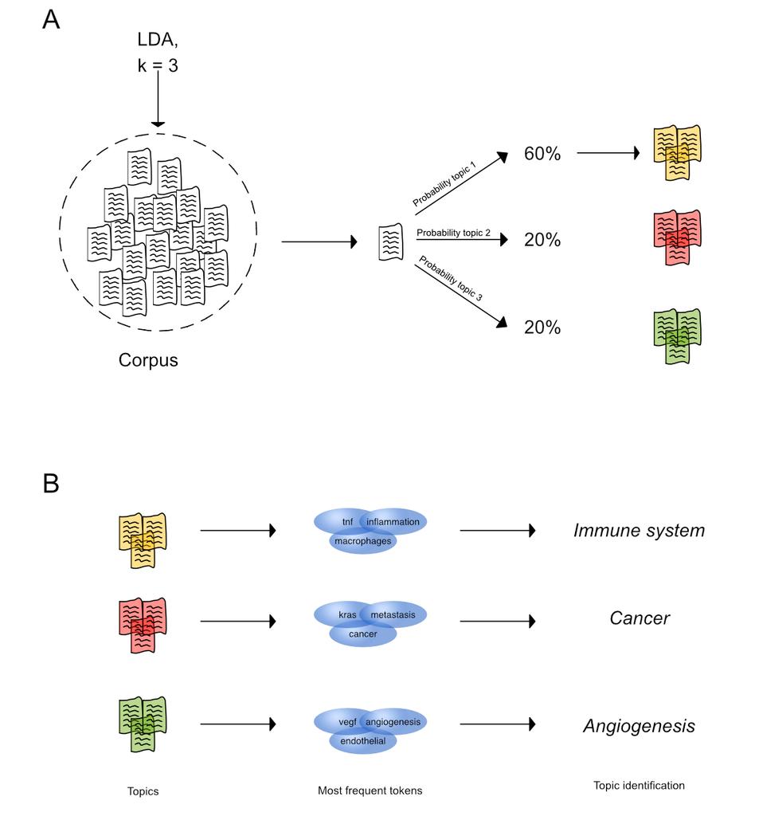

Figure 2.3: **Unsupervised topic modeling with LDA.** **(A)** LDA is fit on a corpus and identifies k = 3 topics based on different criteria. For each text in the corpus, a topic probability to belong to either topic is calculated and the text is assigned to the topic with the highest topic probability.  
**(B)** Tokenizing the texts in a topic and determining their most frequent tokens aids in inferring the main subject of unsupervisedly discovered topics.

This whole process of identifying topics and calculating topic probabilities is referred to as *model fitting*. While an LDA model can be fit with `fit_lda()`, the topics are ultimately assigned to each text with `assign_topic_lda()`. The subjects of the topics can be identified with `plot_lda_terms()`.

```r
# Fit LDA model with k = 4 topics
# Identify 4 topics in df
lda_model <- fit_lda(df,
                     k = 4)

# Identify subject of topics
plot_lda_term(lda_model)

# Assign LDA topics
assign_topic_lda(df,
                 lda_model = lda_model,
                 topic.names = c("Topic1", "Topic2", "Topic3", "Topic4"))
```

As the optimal number of topics for LDA modeling is often unknown, one approach is to fit many LDA models, which differ in topic number, and to compare their *perplexity* (Fig. 2.4). In LDA, perplexity measures how well a model fits the topics, while a lower perplexity corresponds to a better model. When comparing the perplexity of LDA models with different topic numbers, an increase in topic number often leads to a steep decrease in model perplexity at the beginning, indicating a model improvement with an increase in topic number. After a certain point, however, further increasing the topic number often leads to a marginal decrease in perplexity only, indicating that the model improves only marginally with an increase in topic number. The topic number where the decrease in perplexity starts to flatten is usually a good starting point for LDA modeling in practice.

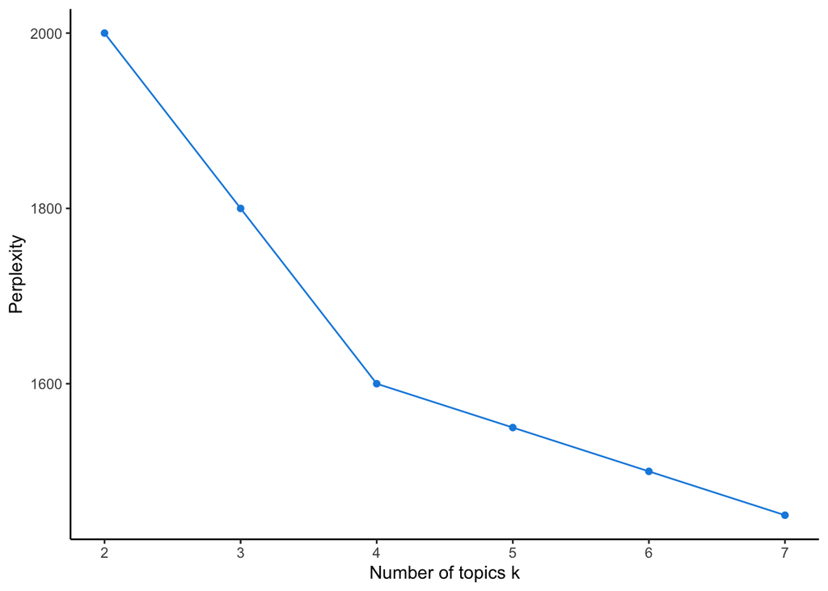

Figure 2.4: **Perplexity ‘elbow’ plot comparing the perplexity of LDA models over a range of topic numbers.**  
Fitting LDA models over k = 2, k = 3, and k = 4 topics considerably decreases the perplexity. Fitting LDA models over further k = 5, k = 6, and k = 7 topics, however, decreases the perplexity only slightly, indicating a marginal model improvement with k > 4. This suggests k = 4 topics as a practical starting point to explore LDA topic modeling in this corpus.

In miRetrieve, the perplexity of different LDA models can be compared with `plot_perplexity()`. `plot_perplexity()` fits LDA models over different topic numbers and compares their perplexity in an *elbow plot*.

```r
# Plot perplexity for 2 to 5 topics
# Identify optimal topic number
plot_perplexity(df, start = 2, end = 5)
```

# 3 miRetrieve functions

In the following section, we are going to describe how to use and combine the functions in miRetrieve.

First, we are going to outline how to load, prepare, and save for and from analysis. Afterwards, we are going to explain how to analyze the miRNA landscape in one subject, before describing how to compare the miRNA landscape of multiple subjects.

## 3.1 Load, prepare, and save data

### 3.1.1 Load data

miRetrieve is optimized to work with PubMed abstracts in MEDLINE or xml-format, which can be downloaded from PubMed via *Send to* –> *File* –> *Format: MEDLINE/xml* –> *Create File*.

The resulting MEDLINE/.xml-file can be loaded into R with either `read_pubmed_medline()` or `read_pubmed_xml()` respectively. As `read_pubmed_medline()` is faster than `read_pubmed_xml()`, it is recommended to use MEDLINE-files.

When loading abstracts with `read_pubmed_*()`, all abstracts can be assigned a `Topic` column, which denotes the subject of a file and facilitates miRNA comparison between topics. If a `Topic` column is not specified while loading, it can also be added with `add_col_topic()`.

```r
# Read in MEDLINE-file from diabetes abstracts
# Denote abstracts as "Diabetes"
df <- read_pubmed_medline("medlinefile_diabetes.txt", topic = "Diabetes")

# Is the same as
df <- read_pubmed_medline("medlinefile_diabetes.txt")
df <- add_col_topic(df, topic.name = "Diabetes")
```

Multiple files can be combined into one data frame with `combine_df()`, which is crucial when comparing miRNAs of multiple topics.

```r
# Load first MEDLINE-file
df1 <- read_pubmed_medline("medlinefile1.txt",
                           topic = "cANCA")

# Load second MEDLINE-file
df2 <- read_pubmed_medline("medlinefile2.txt",
                           topic = "pANCA")

# Combine df1 and df2
df_large <- combine_df(df1, df2)
```

### 3.1.2 Prepare data

#### 3.1.2.1 Subset abstracts

Abstracts loaded into R can be subset for original research or review articles with `subset_research()` and `subset_review()` respectively. Furthermore, abstracts can also be subset for a specific publishing period with `subset_year()`.  
Subsetting abstracts with `subset_*()` keeps only abstracts of interest, while abstracts belonging to another article type or published outside the defined period are dropped.

```r
# Subset for abstracts of original research articles
df_research <- subset_research(df)
```

#### 3.1.2.2 Extract miRNA names

One of the core functions of miRetrieve the extraction of miRNA names from abstracts with `extract_mir_df()`. Extracted miRNA names are stored in a separate `miRNA` column, where each miRNA name occupies one row.

Next to extracting miRNA names from abstracts, miRNA names can also be extracted from single strings with `extract_mir_string()`.

Both `extract_mir_*()` functions extract miRNA names either without or with a possible trailing letter (e.g. *miR-23* or *miR-23a*). As the use of miRNA nomenclature is rather inconsistent throughout literature, it is recommended to ignore trailing letters with `extract_letters = FALSE`[^4].

Furthermore, `extract_mir_*()` has a `threshold` argument determining how often a miRNA must be in an abstract/string to be extracted.

```r
# Extract miRNA names mentioned at least twice in an abstract without trailing letters
extract_mir_df(df,
               threshold = 2,
               extract_letters = FALSE)

# Extract miRNA names from a string with trailing letters
extract_mir_string("miR-146a is an important miRNA in inflammation.",
                   extract_letters = TRUE)
```

#### 3.1.2.3 Subset and indicate miRNA names

After extracting miRNA names, abstracts can be subset for miRNAs with `subset_mir()` and `subset_mir_threshold()`.  
While `subset_mir()` subsets abstracts for specified miRNAs, `subset_mir_threshold()` subsets abstracts for miRNAs that are mentioned with a determined frequency. This frequency can either be an integer, corresponding to the minimal number of abstracts a miRNA is mentioned in, or it can be a decimal between 0 and 1, corresponding to the minimal relative number of abstracts a miRNA is mentioned in.

```r
# Keep only abstracts with miR-126 and miR-146
df_mir126_miR_146 <- subset_mir(df,
                                mir.retain = c("miR-126", "miR-146"))

# Keep only abstracts with miRNAs mentioned in at least 5% of all abstracts
df_five_ab <- subset_mir_threshold(df,
                                   threshold = 0.05)
```

Instead of subsetting abstracts for a specific miRNA, abstracts with a specific miRNA can also be labelled with `indicate_mir()`. Per specified miRNA name in `indicate_mir()`, a separate *Yes/No* column is added indicating the presence of the miRNA in the abstract.

```r
# Indicate abstracts with miR-126 and miR-146
df_mir126_miR_146 <- indicate_mir(df,
                                  indicate.mir = c("miR-126", "miR-146"))

# Save data frame as an .xlsx file
# Filter for miR-126 and miR-146 in excel
save_excel(df_mir126_miR_146,
           excel_file = "df_mir_126146.xlsx")
```

#### 3.1.2.4 Subset data frame

While many functions of the `subset_*()` and `indicate_*()` family provide the possibility of subsetting a data frame, each data frame can also be individually subset with `subset_df()`.  
`subset_df()` is a wrapper of **dplyr**’s `filter()`.

```r
# Subset data frame with customized arguments
subset_df(df,
          col.filter = miRNA,
          filter_for = "miR-126")

# `subset_df()` is a more general version of
subset_mir(df, "miR-126")
```

### 3.1.3 Save data

During analysis, any data frame or graph can be saved locally with `save_excel()` or `save_plot()` respectively.

#### 3.1.3.1 Save data frame to excel

`save_excel()` saves a data frame as an .xlsx-file. When more than one data frame is passed to `save_excel()`, each data frame is saved as a separate work sheet in the same .xlsx-file.

```r
# Save df1 and df2 to the same .xlsx-file
save_excel(df1, df2,
           excel_file = "miRetrieve_df.xlsx")
```

#### 3.1.3.2 Save plots

`save_plot()` saves the last generated plot, while the plot properties can be defined with `width`, `height`, and `dpi`. `save_plot()` is a wrapper of **ggplot2**’s `ggsave()`.

```r
# Save last plot
save_plot("Last_plot.pdf",
          height = 5,
          width = 7,
          dpi = 300)
```

### 3.1.4 Extract PubMed-IDs

PubMed-IDs can be extracted from a data frame with `get_pmid()`. By default, `get_pmid()` copies the PubMed-IDs to the clipboard, which can be used further outside R.  
Additionally, `get_pmid()` can also extract PubMed-IDs as a string by setting `copy = FALSE`.

```r
# Copy PubMed-IDs to clipboard
get_pmid(df,
         copy = TRUE)
```

## 3.2 miRNA text mining in one subject

The following section focuses on miRNA text mining in one subject, opposed to miRNA text mining in several subjects.

Here, we are going to describe how to count miRNAs and display their development. Next, we are going to explain how to display which terms a miRNA is associated with, before illustrating how to visualize which targets miRNAs regulate.

The functions in this section require the miRNAs names to be extracted with `extract_mir_*()`.

### 3.2.1 Count miRNAs

How many abstracts mention a miRNA can be identified either with `count_mir()` or `plot_mir_count()`. While `count_mir()` displays the miRNA count in a data frame, `plot_mir_count()` visualizes the count of the most frequently mentioned miRNAs.

```r
# Count how many abstracts mention a miRNA
count_mir(df)

# Plot the count of the five most frequently mentioned miRNAs
plot_mir_count(df,
               top = 5)
```

### 3.2.2 Count exceeding miRNAs

Next to counting how many abstracts mention one miRNA, counting how many miRNAs are mentioned in a minimal number of abstracts can be done with `count_mir_threshold()` or `plot_mir_count_threshold()`.

Counting how many miRNAs are mentioned in a minimal number of abstracts provides information if the majority of abstracts focus on a few miRNAs only, or if the interest in several miRNAs is evenly distributed across a field.

`count_mir_threshold()` accepts a `threshold` argument and counts how many miRNAs are mentioned in at least `threshold` abstracts. `threshold` can either be an integer, counting how many miRNAs are mentioned in a minimal number of abstracts, or it can be a decimal between 0 and 1, counting how many miRNAs are mentioned in a relative number of abstracts compared to all abstracts.

`plot_mir_count_threshold()` displays the count of miRNAs over several thresholds. Similar to `count_mir_threshold`, the thresholds can either be integers or decimals.

```r
# Count how many miRNAs are mentioned in at least 5 abstracts
count_mir_threshold(df,
                    threshold = 5)

# Plot how many miRNAs are mentioned in at least 5 to 10 abstracts
plot_mir_count_threshold(df,
                         start = 5,
                         end = 10)
```

### 3.2.3 Count miRNAs per year

How often a miRNA was mentioned per year can be visualized with `plot_mir_development()`.

```r
# Plot development of miR-126 and miR-146
plot_mir_development(df,
                     mir = c("miR-126", "miR-146"))
```

### 3.2.4 Count new miRNAs per year

How many miRNAs are mentioned for the first time in a year can be displayed with `plot_mir_new()`.

Displaying how many miRNAs are mentioned for the first time in a year estimates the dynamism of a field, e.g. if recent abstracts mention miRNAs previously not reported, or if recent abstracts focus on miRNAs already mentioned in previous years.

`plot_mir_new()` also provides a `threshold` argument determining in how many abstracts of a year a miRNA must be mentioned to be considered *mentioned*. By setting a `threshold`, miRNAs that are only sparsely mentioned in a year are ignored.

```r
# Plot newly mentioned miRNAs per year
# miRNAs need to be reported in at least 3 abstracts/year
# to be considered "mentioned"
plot_mir_new(df,
             threshold = 3)
```

### 3.2.5 Associate miRNAs with terms

Terms often associated with a miRNA can be visualized using `plot_mir_terms()`.

While `plot_mir_terms()` performs single word tokenization by default, `plot_mir_terms()` can also perform n-gram tokenization by setting `token = ngrams` and specifying a separate `n` argument.

```r
# Plot top terms of miR-126
plot_mir_terms(df,
               mir = "miR-126")

# Plot top 2-grams of miR-126
plot_mir_terms(df,
               mir = "miR-126",
               token = "ngrams",
               n = 2)
```

Next to plotting the top terms as a bar plot, top terms can also be visualized as a word cloud with `plot_wordcloud()`.[^5]

```r
# Word cloud of miR-126
plot_wordcloud(df,
               mir = "miR-126")
```

### 3.2.6 Indicate terms

Abstracts can be screened for terms with `indicate_term()`. Per term, `indicate_term()` signals it presence in an abstract with a separate *Yes/No* column.

How often a term must be in an abstract to be considered *present* can be controlled with a `threshold` argument. Furthermore, `indicate_term()` can also keep only abstracts containing the term(s) of interest via the `discard` argument. A possible application is to keep abstracts that mention a certain drug, and to re-count the most frequent miRNAs in this subset.

```r
# Indicate and keep abstracts that mention "metformin" at least twice
abstracts_metformin <- indicate_term(df,
                                     term = "metformin",
                                     threshold = 2,
                                     discard = TRUE)

# Count miRNAs in "metformin" abstracts
count_mir(abstracts_metformin)
```

### 3.2.7 Identify miRNA targets

miRetrieve can integrate miRNA targets from excel files such as *miRTarBase*[4] with `join_targets()`.

`join_targets()` loads an excel-file with PubMed-IDs and miRNA targets and adds it to a miRetrieve data frame by matching their PubMed-IDs.

```r
# Adds targets from miRTarBase (see "References") to df
df_targets <- join_targets(df,
                           excel_file ="miRTarBase_MTI.xlsx",
                           col.pmid.excel = "References (PMID)",
                           col.target.excel = "Target Gene",
                           col.mir.excel = "miRNA")
```

After adding the targets, target frequency can be counted with `count_target()` or visualized with `plot_target_count()`.

```r
# Count target frequency
count_target(df_targets)

# Plot target frequency
plot_target_count(df_targets)
```

Furthermore, miRNA-target interactions can be plotted with `plot_target_mir_scatter()`.  
`plot_target_mir_scatter()` plots either the most frequently targeted genes, or it plots the top miRNAs targeting genes. If the focus shall be on the top targets or top targeting miRNAs, can be regulated via the `filter_for` argument.

```r
# Plot most frequently targeted genes
plot_target_mir_scatter(df_targets,
                        filter_for = "target")

# Plot most frequently targeting miRNAs
plot_target_mir_scatter(df_targets,
                        filter_for = "miRNA")
```

### 3.2.8 Single Nucleotide Polymorphism

Single Nucleotide Polymorphisms (SNPs) can be extracted from abstracts with `extract_snp()`.

`extract_snp()` retrieves SNPs from abstracts and stores them in a column. Unlike `extract_mir_df()`, however, all extracted SNPs of an abstract are stored in the same row. Furthermore, `extract_snp()` can also subset abstracts containing SNPs via the `discard` argument.

```r
# Exctract SNPs
# Keep only abstracts with SNPs
snp_df <- extract_snp(df,
                      discard = TRUE)
```

Extracted SNPs can be counted with `count_snp()`, while abstracts can be subset for specific SNPs with `subset_snp()`.  
To facilitate filtering for SNPs, SNP names can be extracted from a data frame with `get_snp()`. `get_snp()` retrieves the string of a SNP by row, which can be passed to `subset_snp()`.

```r
# Count SNPs
snp_count_df <- count_snp(snp_df)

# Extract SNP name in the second row of snp_count_df
second_snp_string <- get_snp(snp_count_df,
                             row = 2)

# Subset `snp_df` for abstracts containing `second_snp_string`
subset_snp(snp_df,
           snp.retain = second_snp_string)
```

## 3.3 miRNA text mining in multiple subjects

Next to miRNA text mining in a single subject, miRetrieve also offers tools to compare the results of miRNA text mining in multiple subjects.

In this section, we are going to explain how to compare miRNA count and miRNA-term association. Furthermore, we are going to describe how to visualize miRNA-target interactions across fields.

### 3.3.1 Data preparation

To compare different subjects, each subject is loaded separately with `read_pubmed_*()`. Furthermore, each field must be assigned a distinct topic name, using either the `topic` argument of `read_pubmed_*()` or `add_col_topic()`. Afterwards, all files are combined for further analysis with `combine_df()`.

```r
# Load abstracts of the first topic
df1 <- read_pubmed_medline(medline_file1, topic = "Virus")

# Load abstracts of the second topic
df2 <- read_pubmed_medline(medline_file2, topic = "Bacteria")

# Combine abstracts of topics
df_combined <- combine_df(df1, df2)
```

### 3.3.2 Extract miRNA names as strings

A key difference to text mining in one subject is that the miRNAs to analyze must be specified.

For this, miRNA names can be extracted as strings from a data frame using `get_mir()`, `get_shared_mir*()`, `get_distinct_mir_*()`, and `combine_mir()`.

- `get_mir()` extracts either the most frequently mentioned miRNAs or the miRNAs that are mentioned in a minimum number of abstracts.  
  Moreover, `get_mir()` can also extract the top miRNAs of one subject with a `topic` argument.

  ```r
  # Get top 5 miRNAs of all topics
  get_mir(df_combined,
          top = 5)

  # Get top 5 miRNAs of the topic "Atherosclerosis"
  get_mir(df_combined,
          top = 5,
          topic = "Atherosclerosis")
  ```

- `get_shared_mir*()` provides the most frequent miRNAs that are shared between two subjects. `get_shared_mir_df()` extracts the shared miRNAs from a data frame, while `get_shared_mir_vec()` extracts the shared miRNAs from two character vectors.

  ```r
  # Get top shared miRNAs of "T1DM" and "T2DM"
  get_shared_mir_df(df_combined,
                    topic = c("T1DM", "T2DM"))
  ```

- `get_distinct_mir*()` provides the most frequent miRNAs that are distinct for one topic, but do not belong to the top miRNAs of another topic. `get_distinct_mir_df()` extracts the distinct miRNAs from a data frame, while the topic to extract the distinct miRNAs from is determined with the `distinct` argument.  
  `get_distinct_mir_vec()` extracts the distinct miRNAs of the first character vector from two character vectors.

  ```r
  # Get top miRNAs distinct for "ALL" compared to "AML"
  get_distinct_mir_df(df_combined,
                      distinct = "ALL",
                      topic = c("ALL", "AML"))
  ```

- `combine_mir()` combines character vectors with miRNA names into one vector.

  ```r
  # Get top 5 miRNAs of "CML"
  top_topic1 <- get_mir(df_combined,
                        top = 5,
                        topic = "CML")

  # Get top 5 miRNAs of "CLL"
  top_topic2 <- get_mir(df_combined,
                        top = 5,
                        topic = "CLL")

  # Combine vectors
  top_combined <- combine_mir(top_topic1, top_topic2)
  ```

### 3.3.3 Compare miRNA count

How many abstracts per subject mention a miRNA can be compared with `compare_mir_count()`.

`compare_mir_count()` displays either the absolute number of abstracts per subject mentioning a miRNA, or it can display the relative number of abstracts per subject mentioning a miRNA, referring to the number of abstracts with a miRNA relative to all abstracts per subject.  
Furthermore, the relative count of miRNAs can be comperd between two subjects on a log2-scale with `compare_mir_count_log2()`.

```r
# Use `top_combined` from the previous code chunk

# Compare miRNA frequency between topics
compare_mir_count(df_combined,
                  mir = top_combined)

# Compare miRNA frequency between subjects on a log2-scale
compare_mir_count_log2(df_combined,
                       mir = top_combined)
```

### 3.3.4 Identify unique miRNAs

Instead of comparing shared miRNAs, most frequent unique miRNAs of each topic can be displayed with `compare_mir_count_unique()`.

```r
# Identify 5 most frequent unique miRNAs per topic
compare_mir_count_unique(df_combined,
                         top = 5)
```

### 3.3.5 Compare term associations

There are three functions to compare miRNA-term associations across subjects, namely `compare_mir_terms()`, `compare_mir_terms_log2()`, and `compare_mir_terms_scatter()`.

While `compare_mir_terms()` can compare the top term count of a miRNA over many subjects, `compare_mir_terms_log2()` and `compare_mir_terms_scatter()` can compare the top term count of a miRNA over two subjects only.

`compare_mir_terms()` plots the count of top miRNA-term associations, whereas  
`compare_mir_terms_log2()` compares the miRNA-term association between two subjects on a log2-scale.[^6]

```r
# Compare term frequency for miR-126 between topics
compare_mir_terms(df_combined,
                  mir = "miR-126")

# Compare term frequency for miR-126 between two topics on a log2-scale
compare_mir_terms_log2(df_combined,
                       mir = "miR-126")
```

Finally, `compare_mir_terms_scatter()` creates a scatter plot, displaying the frequency of the shared miRNA-associated terms.[^7]

```r
# Compare terms of miR-126 between two topics
mir126_terms <- compare_mir_terms_scatter(df_combined,
                                          mir = "miR-126")
```

### 3.3.6 Identify unique term associations

The most frequent terms a miRNA is associated with in one, but not another topic can be displayed with `compare_mir_terms_unique()`.

```r
# Identify most frequent unique terms of miR-126 per topc
compare_mir_terms_unique(df_combined,
                         mir = "miR-126")
```

### 3.3.7 Compare target interactions

As described previously, targets can be added from an excel file with `join_targets()`. When a data frame contains miRNA-target interactions in multiple subjects, `plot_target_mir_scatter()` colours the miRNA-target interaction by subject, thereby allowing easy comparison of miRNA-target interactions across fields.

# 4 Case study

In the last section, we are going to apply miRetrieve in a small case study.

## 4.1 Introduction

In this fictive case study, our lab detected miR-21 to be aberrantly expressed in colorectal cancer (CRC). Using miRetrieve, we characterize the role of miR-21 in CRC and compare it to its role in pancreatic cancer.

## 4.2 Data preparation

To investigate the role of miR-21 in CRC, we load all PubMed abstracts matching the keywords *colorectal cancer mirna* with `read_pubmed_medline()`. Then, we keep only abstracts of original research articles, using `subset_research()`, and subsequently extract their miRNA names with `extract_mir_df()`.

During our analysis, we use the `%>%` operator from the **magrittr** package. `%>%` passes the result of one function straight into the following function, making our code easier to write, read, and maintain.

```r
# Load miRetrieve
library(miRetrieve)
# Load magrittr
library(magrittr)

# Path to MEDLINE-file
crc_medline <- "CRC_Medline.txt"

# Load MEDLINE-file
df_crc <- read_pubmed_medline(crc_medline,
                              topic = "CRC") %>%
  # Keep abstracts of original research articles
  subset_research() %>%
  # Extract miRNA names
  extract_mir_df()
```

After loading and filtering the abstracts, we have a data frame with 4909 rows and 8 columns, named *PMID, Year, Title, Abstract, Language, Type, Topic, miRNA*. As each miRNA name occupies one row in the `miRNA` column, and each abstract can mention more than one miRNA, there are more rows in the data frame than abstracts under investigation.

## 4.3 Indicate miR-21 in CRC and save file

We know that we are going to need information on miR-21 in the future. We therefore label all abstracts mentioning miR-21 with `indicate_mir()`, and save the table as an .xlsx-file. Saving the table locally will allow us to read and compare PubMed abstracts mentioning miR-21 comfortably.

```r
# Label all abstracts mentioning miR-21 with "Yes"
df_mir21 <- indicate_mir(df_crc,
                         indicate.mir = "miR-21")

# Save as an .xlsx file
save_excel(df_mir21,
           excel_file = "miR21_crc.xlsx")
```

## 4.4 Count miRNAs in CRC

To begin our analysis, we count the top miRNAs in CRC using `plot_mir_count()`. If miR-21 should not be among the top miRNAs, we plan on counting all miRNAs with `count_mir()`, filter the resulting data frame for miR-21 with `subset_df()`, and distinctively determine the count of miR-21.

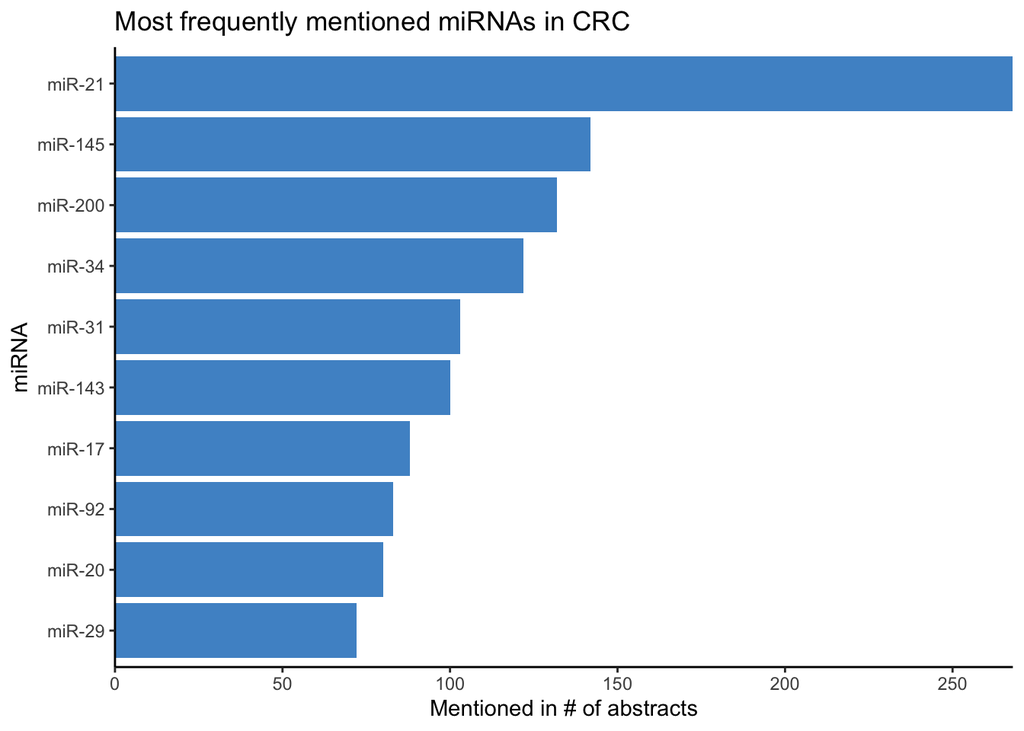

```r
# Plot count of top miRNAs in CRC
plot_mir_count(df_crc,
               title = "Most frequently mentioned miRNAs in CRC")
```

In CRC, miR-21 seems to be the most frequently mentioned miRNA, being reported in more than 250 abstracts. Next to miR-21, miR-145, miR-200, and miR-34 are also mentioned frequently in CRC.

## 4.5 Plot miR-21 associated terms in CRC

As miR-21 is likely well investigated in CRC, we identify which terms miR-21 is associated with using `plot_mir_terms()`.

To analyze the terms miR-21 is associated with, we choose to tokenize the text into single words and into 2-grams.

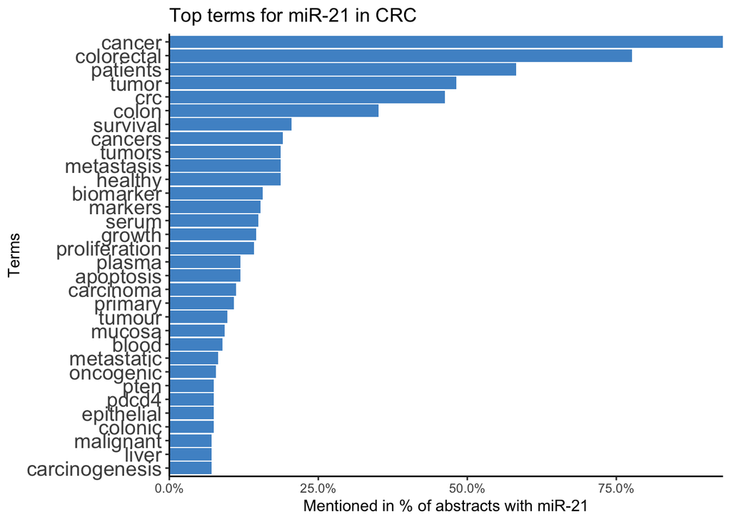

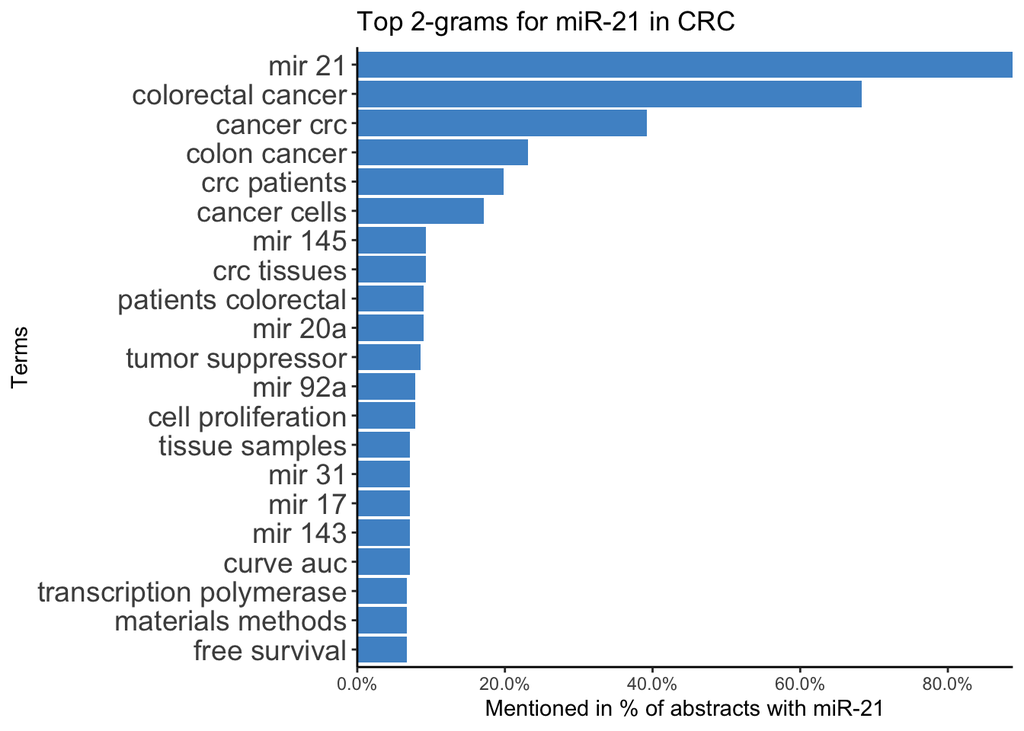

```r
# Plot top single terms associated with miR-21 in CRC
plot_mir_terms(df_crc,
               "miR-21",
               top = 30,
               title = "Top terms for miR-21 in CRC")

# Plot top 2-grams associated with miR-21 in CRC
plot_mir_terms(df_crc,
               "miR-21",
               token = "ngrams",
               n = 2,
               title = "Top 2-grams for miR-21 in CRC")
```

The top single terms for miR-21 suggest that miR-21 is associated with *survival*, even though *survival* is most likely a word common in cancer literature. Furthermore, it is implied that miR-21 targets *PTEN* and *PDCD4*. As miR-21 is also often associated with *serum*, *plasma*, and *biomarker*, miR-21 might be a biomarker.

The 2-gram tokenization implies that miR-21 is frequently mentioned with miR-145, miR-20a, miR-92a, and miR-31, which hints at possible miR-miR interactions and co-regulations.

## 4.6 miRNAs as biomarkers in CRC

As miR-21 might be a biomarker in CRC, we determine the most frequently mentioned miRNAs in biomarker abstracts.

Here, we first subset for biomarker abstracts with `calculate_score_biomarker()` and setting `discard = TRUE`.  
As `calculate_score_biomarker()` requires a threshold to distinguish abstracts with and without biomarker, we try to determine a reliable threshold using `plot_score_biomarker()`.

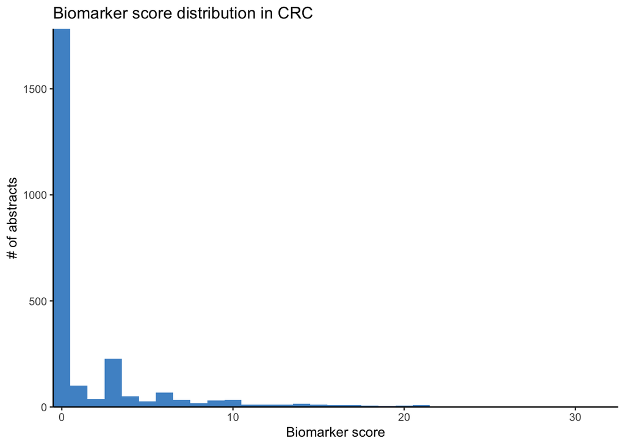

```r
# Plot score distribution for biomarker in CRC
plot_score_biomarker(df_crc,
                     title = "Biomarker score distribution in CRC")
```

While the majority of abstracts do not seem to report miRNAs as biomarkers in CRC, using a threshold above 5 in `calculate_score_biomarker()` seems reasonable. After identifying abstracts describing biomarkers, we count the top miRNAs with `plot_mir_count()`.

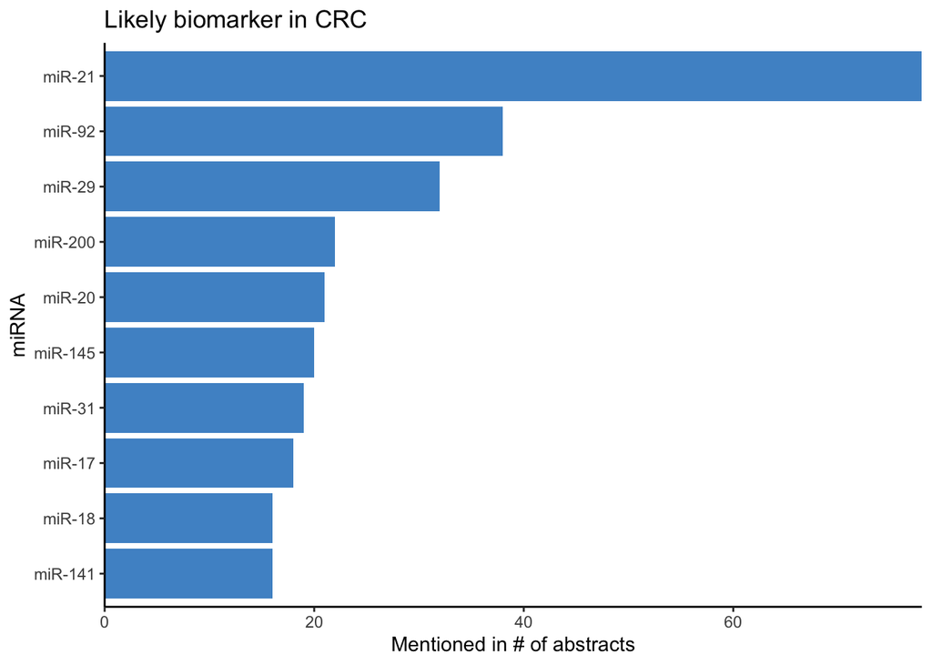

```r
# Identify abstracts reporting miRNAs as biomarker in CRC
crc_biomarker <- calculate_score_biomarker(df_crc,
                                           threshold = 5,
                                           discard = TRUE)

# Plot top potential biomarker miRNAs in CRC
plot_mir_count(crc_biomarker,
               title = "Likely biomarker in CRC")
```

miR-21 is mentioned in more than 50 abstracts potentially reporting biomarkers, and thus very likely to be a biomarker in CRC.

## 4.7 miRNAs as biomarkers in pancreatic cancer

To determine if miR-21 is a specific biomarker for CRC, we compare it to possible miRNA biomarkers in another cancer entity, namely pancreatic cancer.

First, we load abstracts matching the keywords *pancreatic cancer mirna*, keep only abstracts of original research articles, and extract their miRNA names. Next, we identify the top possible biomarker miRNAs with `plot_score_biomarker()`, `calculate_score_biomarker()`, and `plot_mir_count`. If miR-21 is not among the top biomarker miRNAs in pancreatic cancer, we subset all biomarker abstracts for miR-21 with `subset_df()` and count miR-21 selectively with `count_mir()`.

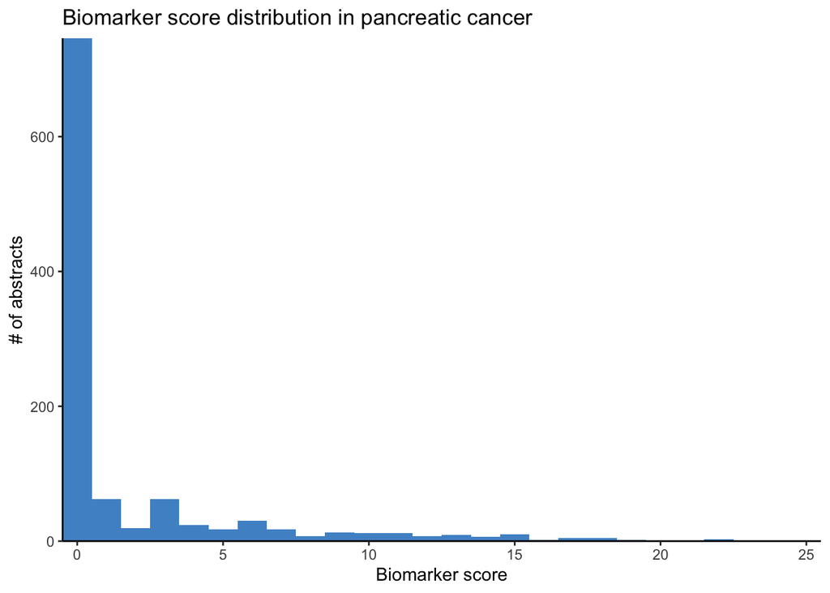

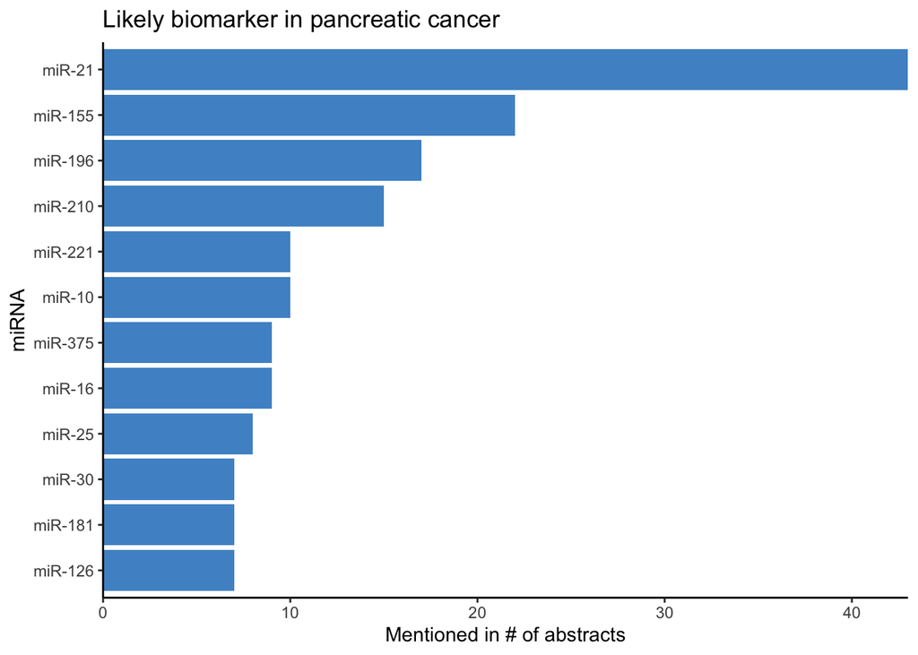

```r
# Path to MEDLINE-file
panc_medline <- "Pancreas_Medline.txt"

# Load MEDLINE-file
df_panc <- read_pubmed_medline(panc_medline,
                              topic = "Pancreas") %>%
  # Keep original research articles
  subset_research() %>%
  # Extract miRNA names
  extract_mir_df()

# Plot score distribution for biomarker in pancreatic cancer
plot_score_biomarker(df_panc,
                     title = "Biomarker score distribution in pancreatic cancer")

# Identify abstracts reporting miRNAs as biomarker in pancreatic cancer
panc_biomarker <- calculate_score_biomarker(df_panc,
                                           threshold = 6,
                                           indicate = TRUE,
                                           discard = TRUE)

# Plot top potential biomarker miRNAs in pancreatic cancer
plot_mir_count(panc_biomarker,
               title = "Likely biomarker in pancreatic cancer")
```

## 4.8 Target interactions of miR-21 in CRC and pancreatic cancer

As miR-21 seems to be a biomarker in CRC and pancreatic, we determine if miR-21 also shares miRNA-target interactions in both tumor entities.

First, we combine the CRC and pancreatic cancer data frames with `combine_df()`. Next, we look up the experimentally validated targets by adding the *miRTarBase*[4] database with `join_targets()`. Finally, we plot the targets of miR-21 with `plot_target_mir_scatter()`.

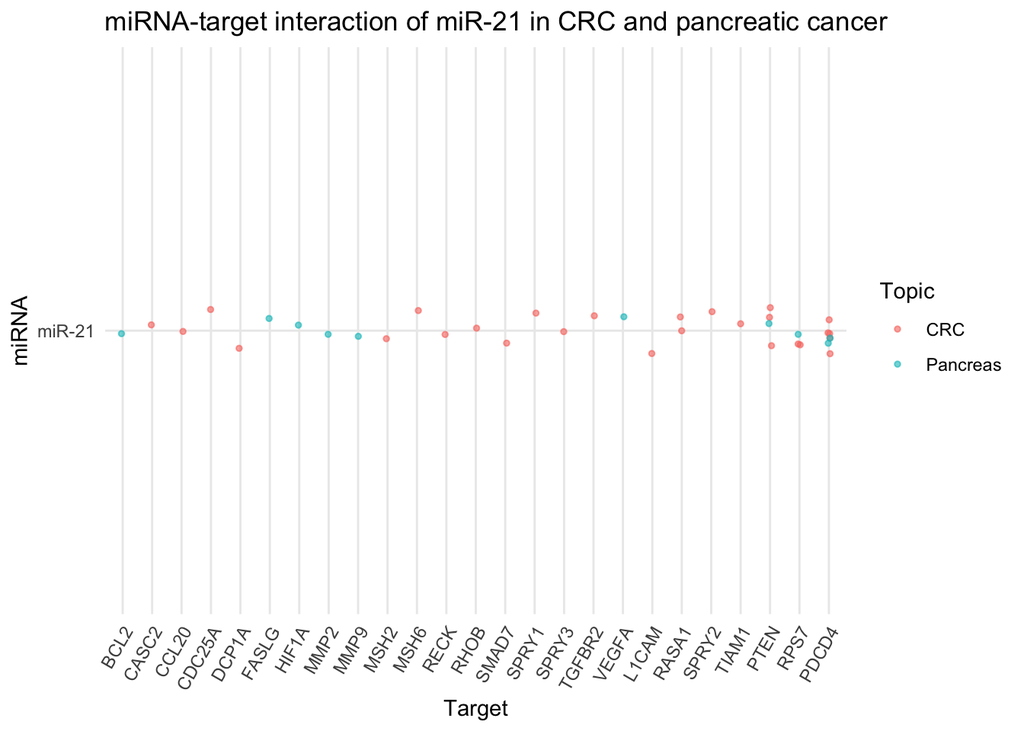

```r
# Combine CRC and pancreatic cancer data frames
df_crc_panc <- combine_df(df_crc, df_panc)

# Path to miRTarBase (see "References")
target_db <- "miRTarBase_MTI.xlsx"

# Add miRTarBase targets to `df_crc_panc`
df_targets <- join_targets(df_crc_panc,
                           excel_file = target_db,
                           col.pmid.excel = "References (PMID)",
                           col.target.excel = "Target Gene",
                           col.mir.excel = "miRNA",
                           stem_mir_excel = TRUE)

# Plot top targets for miR-21 in CRC and pancreatic cancer
plot_target_mir_scatter(df_targets,
                        mir = "miR-21",
                        col.mir = miRNA_excel,
                        top = 10,
                        filter_for = "target",
                        title = "miRNA-target interaction of miR-21 in CRC and pancreatic cancer")
```

According to *miRTarBase*, miR-21 shares at least three targets across CRC and pancreatic cancer, namely *PDCD4*, *PTEN*, and *RPS7*. However, miR-21 is also known to target only specific genes in one subject so far, such as *RASA1*, *SPRY2*, or *TIAM1* in CRC, or *BCL2*, *FASLG*, *HIF1A*, *MMP2*, or *MMP9* in pancreatic cancer.

For our project, it is therefore interesting to investigate if miR-21 regulates also one of the uniquely in pancreatic cancer reported targets in CRC.

## 4.9 Top miRNA-target interactions in CRC and pancreatic cancer

Lastly, we identify the three genes that are targeted by most miRNAs in CRC and pancreatic cancer with `plot_mir_scatter()`.

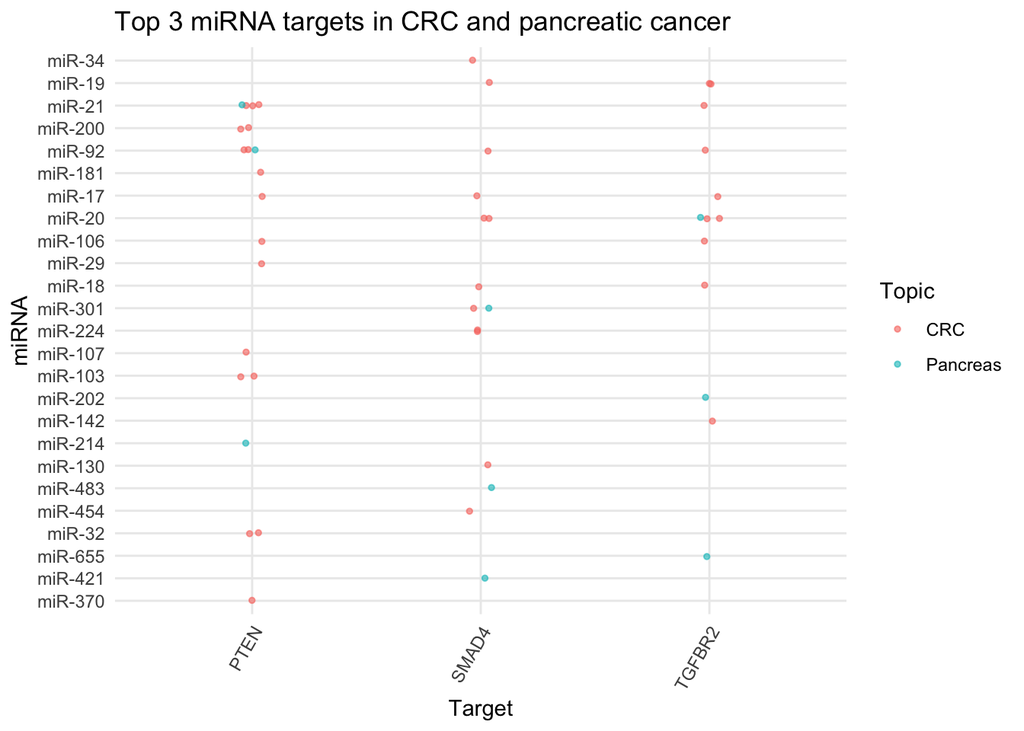

```r
# Plot top 3 miRNA targets in CRC and pancreatic cancer
plot_target_mir_scatter(df_targets,
                        col.mir = miRNA_excel,
                        top = 3,
                        filter_for = "target",
                        title = "Top 3 miRNA targets in CRC and pancreatic cancer")
```

According to *miRTarBase*, *PTEN*, *SMAD4*, and *TGFBR2* are the most targeted genes in CRC and pancreatic cancer. As more miRNAs have been validated to regulate *PTEN*, *SMAD4*, and *TGFBR2* in CRC than in pancreatic cancer, an interesting next step would be to investigate if the same mechanisms also take place in pancreatic cancer.

## 4.10 Conclusion

With few lines of code, we determined that miR-21 is a frequently mentioned and thus most likely well investigated miRNA in CRC. Furthermore, we revealed that miR-21 is possibly a non-specific biomarker for CRC and pancreatic cancer. Next to that, we gained insight into common and distinct targets of miR-21 in both diseases, while also observing that *PTEN*, *SMAD4*, and *TGFBR2* are targeted by multiple miRNAs in both fields.

While the mention of a miRNA and the terms it is associated with in an abstract need to be interpreted carefully, text mining miRNAs with miRetrieve provides the opportunity to generate and test hypotheses on the fly, which can serve as a starting point for subsequent research.

# References

[1] Silge J, Robinson D. Tidytext: Text mining and analysis using tidy data principles in r. JOSS 2016;1. https://doi.org/10.21105/joss.00037.

[2] Grün B, Hornik K. topicmodels: An R package for fitting topic models. Journal of Statistical Software 2011;40:1–30. https://doi.org/10.18637/jss.v040.i13.

[3] Fellows I. Wordcloud: Word clouds. 2018.

[4] Chou CH, Shrestha S, Yang CD, Chang NW, Lin YL, Liao KW, et al. MiRTarBase update 2018: A resource for experimentally validated microRNA-target interactions. Nucleic Acids Res 2018;46:D296–d302. https://doi.org/10.1093/nar/gkx1067.

[^1]: https://www.lexico.com/en/definition/natural_language_processing
[^2]: English stop words are based on `tidytext::stop_words`[1].
[^3]: English stop words removed for n-gram tokenization are based on `tidytext::stop_words`[1].
[^4]: If there is interest in a miRNA with trailing letters, e.g. *miR-23a* or *miR-23b*, an alternative is to plot the top associated 2-grams of the miRNA with `plot_mir_terms()`, which can display the most frequent combination of miRNA/trailing letter in literature
[^5]: `plot_wordcloud()` is based on the **wordcloud** package[3].
[^6]: The plot created by `compare_mir_terms_log2()` is greatly inspired by *Text Mining with R* by Silge and Robinson[1].
[^7]: The plot generated by `compare_mir_terms_scatter()` is greatly inspired by *Text Mining with R* by Silge and Robinson[1].